# Homework 04: Data Cleaning

Gregory Moses

## Part 1 (curve balls)

Instructions: Determine what makes a successful curveball. Then, determine which pitcher pitches the most successful curve balls. Use the “count” command to count the total number of curveballs.

Although the instructions in Canvas mention velocity, that is not in our data set. We’ll look only at the spin rate.

```r
pitch <- read_csv("http://srvanderplas.github.io/rwrks/03-r-format/data/pitch.csv")
```

Not knowing anything about baseball, I’ll start by looking at the summary information for the various outcomes. It seemed like “action_result” should be more relevant than “ab_result” since we are looking at individual pitches.

```r
pitch_with_errors<-pitch[pitch$pitch_type=="CU",]
pitch<-na.omit(pitch)


pitch %>% group_by(action_result) %>%
  summarise(
  mean_spin = mean(spin_rate),
  median_spin = median(spin_rate),
  )
```

```
## # A tibble: 5 × 3
##   action_result mean_spin median_spin
##   <chr>             <dbl>       <dbl>
## 1 B                 3119.       3085.
## 2 C                 3127.       3097.
## 3 F                 3135.       3095.
## 4 S                 3130.       3089.
## 5 X                 3130.       3101.
```

Our intuition is that if we’re keeping track of rpm, it should be because rpm is correlated to outcome; for example, a batter is less likely to hit a ball thrown with a high rpm. From the table, that doesn’t obviously seem to be true, but let’s approach the question more formally by asking if the outcomes have different means.

```r
bartlett.test(spin_rate ~ action_result, data = pitch)
```

```
##
##  Bartlett test of homogeneity of variances
##
## data:  spin_rate by action_result
## Bartlett's K-squared = 5, df = 4, p-value = 0.3
```

```r
oneway.test(spin_rate ~ action_result, data = pitch, var.equal = TRUE)
```

```
##
##  One-way analysis of means
##
## data:  spin_rate and action_result
## F = 2, num df = 4, denom df = 2230, p-value = 0.2
```

Undergraduate statistics was long ago, but if I’m doing this right, we should not reject the null hypothesis, i.e. we should not think that different outcomes have different mean rpms. What about the mysterious “adj_h”?

```r
bartlett.test(adj_h ~ action_result, data = pitch)
```

```
##
##  Bartlett test of homogeneity of variances
##
## data:  adj_h by action_result
## Bartlett's K-squared = Inf, df = 4, p-value <2e-16
```

```r
oneway.test(spin_rate~action_result, data = pitch, var.equal = FALSE)
```

```
##
##  One-way analysis of means (not assuming equal variances)
##
## data:  spin_rate and action_result
## F = 2, num df = 4, denom df = 874, p-value = 0.2
```

```r
summary(pitch$spin_rate)
```

```
##    Min. 1st Qu.  Median    Mean 3rd Qu.    Max.
##    3000    3039    3090    3126    3184    3519
```

```r
good<-filter(pitch,spin_rate>3192 | spin_rate<3042)
```

We’ll now see what player ids got the most of these “good” pitches; we’ll limit ourselves to the top 5.

```r
display<-as.data.frame(table(good$playerid))
colnames(display)<-c("Player","Good_pitches")
truncated<-head(display[order(-display$Good_pitches),],5)
print.data.frame(truncated, row.names = FALSE)
```

```
##  Player Good_pitches
##    2732          173
##   10045          143
##   14344          131
##    1030           53
##    3138           49
```

If we’re willing to buy our definition of a “good curveball,” three players in the data are clearly, radically better than the rest. There are a total of

```r
nrow(display)
```

```
## [1] 59
```

pitchers who’ve thrown at least one good curveball. In total, there were

```r
sum(display$Good_pitches)
```

```
## [1] 1116
```

good curveballs, out of

```r
nrow(pitch_with_errors)
```

```
## [1] 2087
```

curveballs thrown.

### Part 2 (Census data)

In this part of the assignment, we will…

#### Use tidyr to get the data into a long format

```r
census <- read_csv("http://srvanderplas.github.io/rwrks/03-r-format/data/occupation-1870.csv")
job <- census %>% gather(Occupation,number,"Agriculture.Male":"School.Female")
```

#### Seperate occupation.gender into two variables

```r
job$Occupation <- paste(job$Occupation)
job <- job %>% separate(Occupation, c('Occupation', 'Sex'))
```

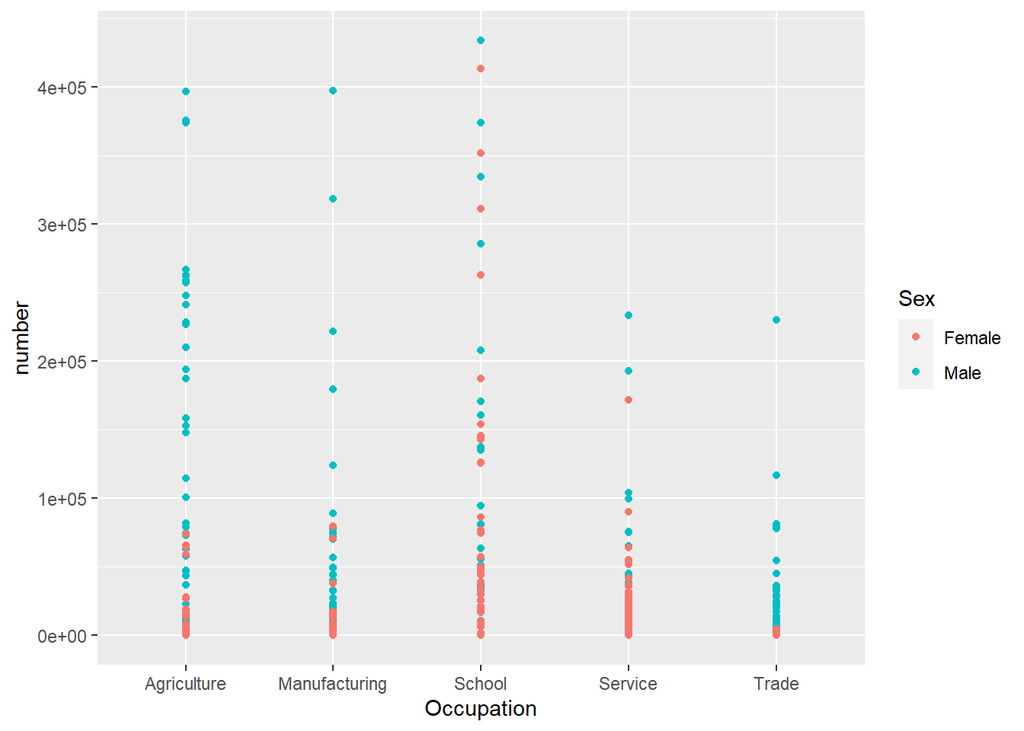

```r
#### Plot occupation vs. sex (dot plot specified)

ggplot(job, aes(x=Occupation, y=number, color=Sex)) + geom_point()
```

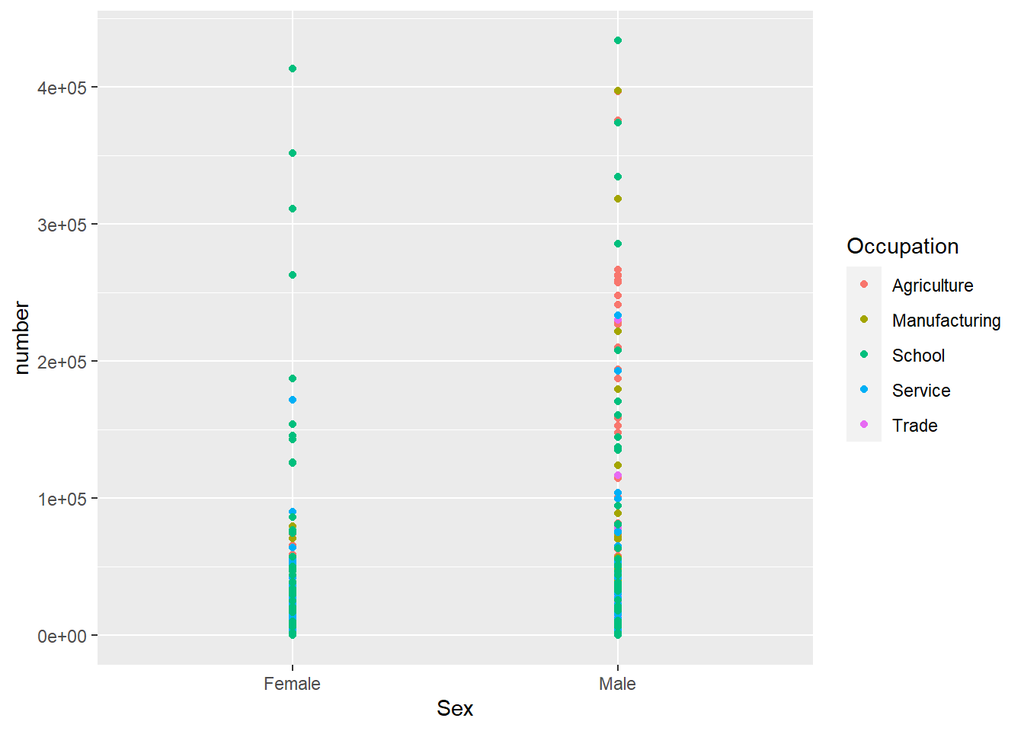

```r
ggplot(job, aes(x=Sex, y=number, color=Occupation)) + geom_point()
```

#### Boxplot

I think that box plots are easier to parse in this case, thanks to the data not covering itself

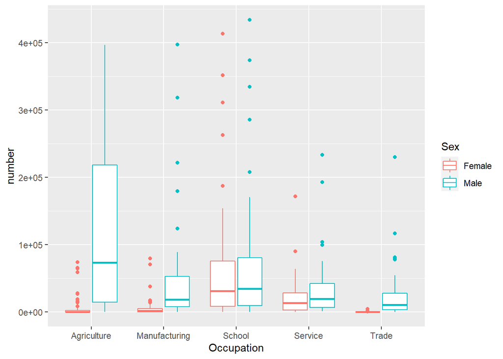

```r
ggplot(job, aes(x=Occupation, y=number, color=Sex)) + geom_boxplot()
```

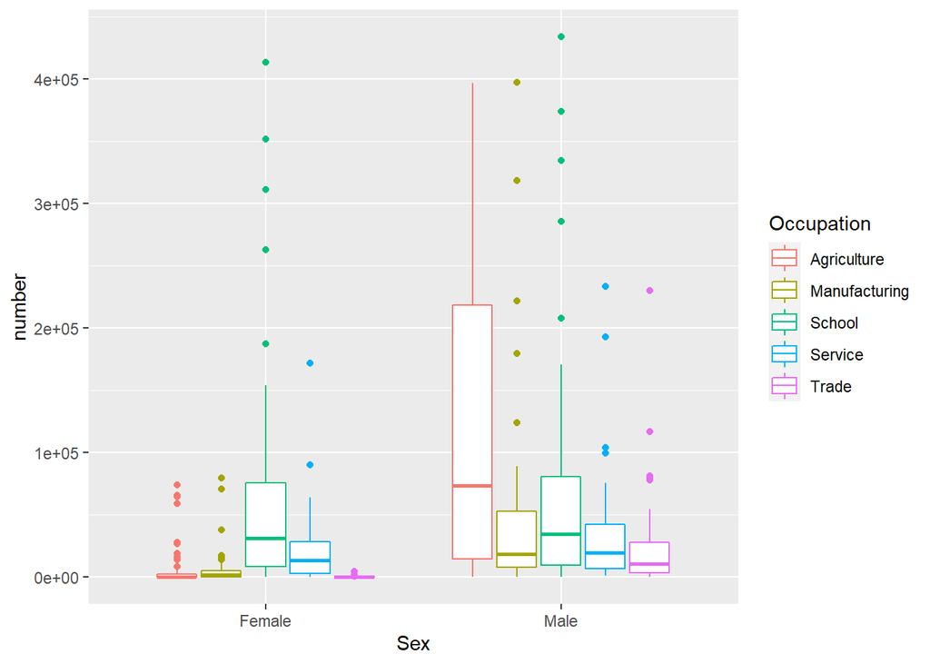

```r
ggplot(job, aes(x=Sex, y=number, color=Occupation)) + geom_boxplot()
```

From the dot or box plots, we see that far more men were employed than woman; that women were basically not employed in agriculture, manufacturing, or trade; and that the only category with something like parity between the sexes was School. Other than School, women were closest to men in Service industries. We also see that for men, the largest industry by a significant margin was Agriculture.